# Differential methylation analysis report EXP24000675_CD81_KAL_silenced_vs_miniTETv1

# Dataset overview

## Reference genome

Reference genome: `hg38_plus_PL2001_transgene_LTR`

## Sample overview

| sample | condition | 10X CpG |
| --- | --- | --- |
| XY1_SILENCE1 | KAL_silenced | 1824 |
| XY2_SILENCE2 | KAL_silenced | 1783 |
| XY5_TET6_1 | dCas9-miniTETv1 | 1639 |
| XY6_TET6_2 | dCas9-miniTETv1 | 1664 |

## Coverage Statistics

CpGs must meet coverage requirements in all samples to be included in analysis.

CD81 region CpGs with at least 10X coverage in all samples:1,526

# PCA

## CpG

PCA analysis on CpG % methylation matrix **X** where **X ( i , j )** represents the % methylation of CpG **j** in sample **i**.

### Biplot

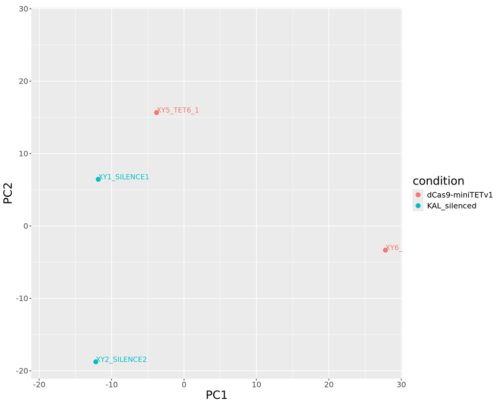

### Scree plot

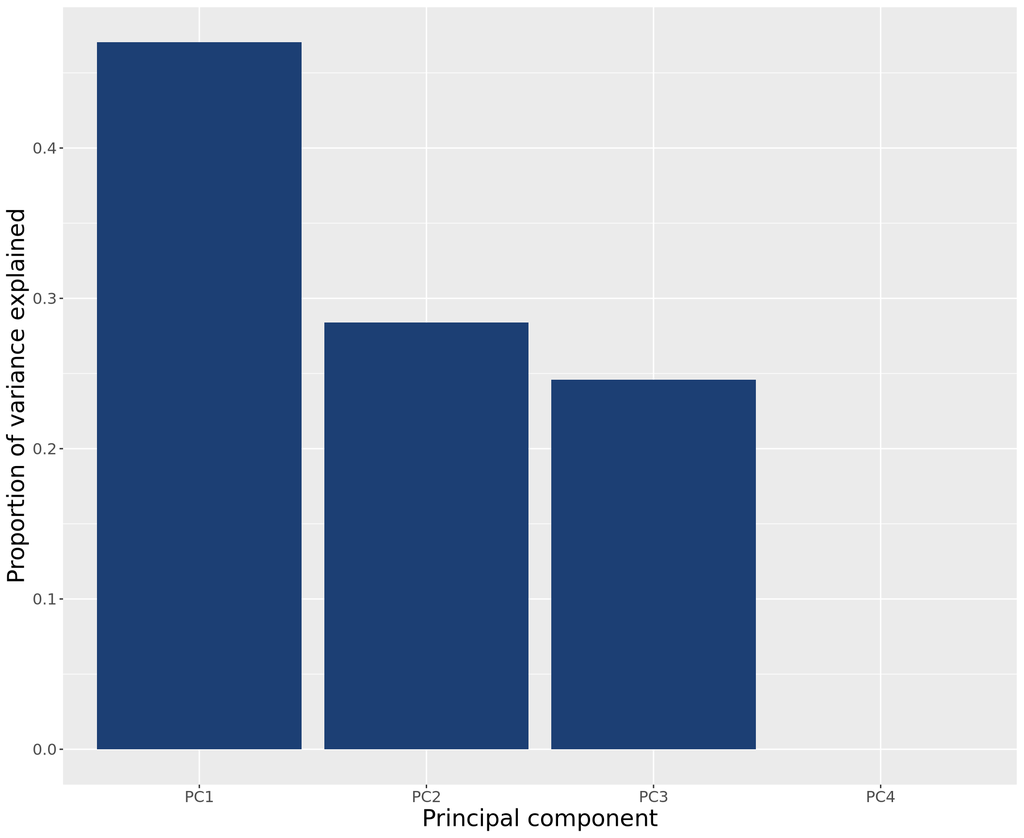

# Heatmap of the sample-to-sample distances

## CpG

Euclidean distances between samples in CpG % methylation matrix.

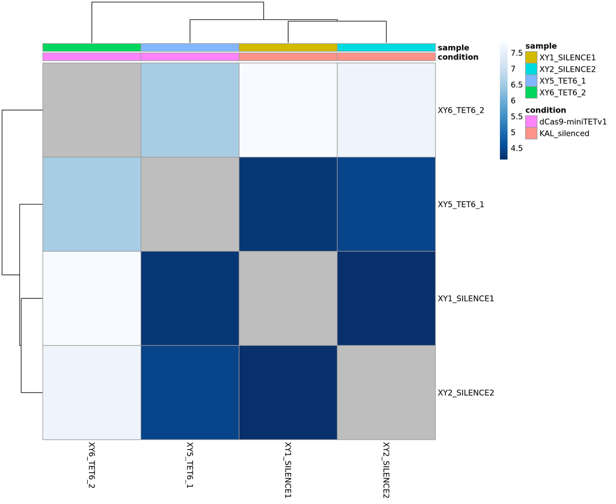

# Differentially methylated bases or regions

## CpG % methylation scatterplot

All 1526 CpGs are plotted with average % methylation in dCas9-miniTETv1 vs KAL_silenced.

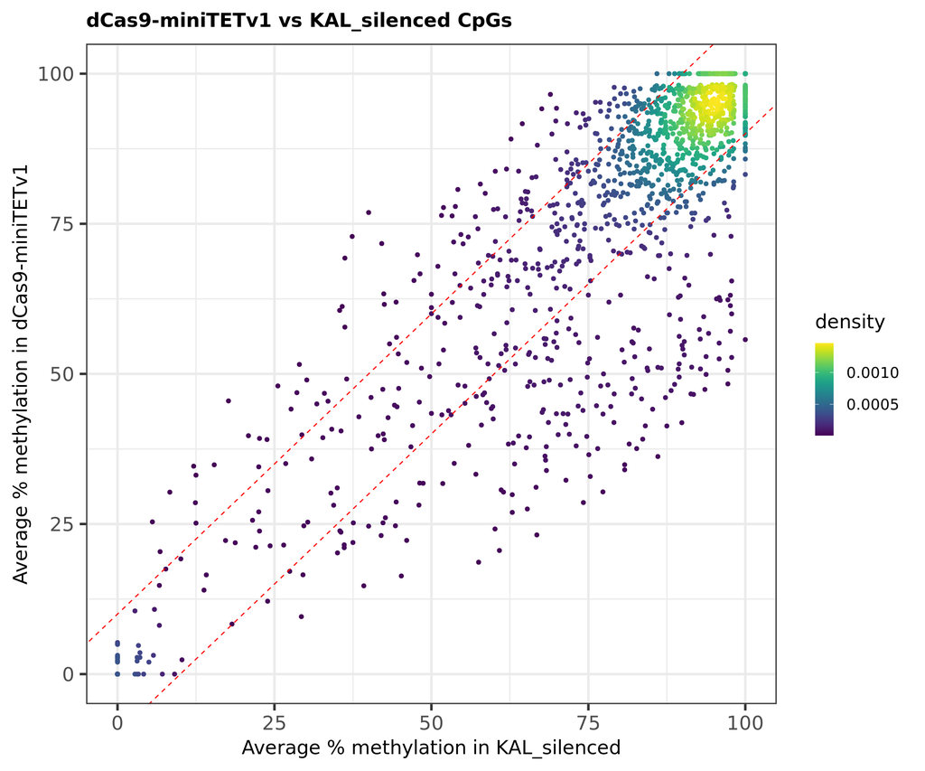

## DMC table

Differentially methylated CpGs are calcualted using methylKit. Depending on the sample size per each set it will either use Fisher’s exact or logistic regression to calculate P-values. P-values will be adjusted to Q-values using SLIM method (Wang, Tuominen, and Tsai 2011). Note: if we have replicates, the function will automatically use logistic regression.

Treatment : dCas9-miniTETv1  
Control : KAL_silenced

**77** DMCs were identified with q-value < 0.05 and % methylation difference > 10.

| chr | start | end | XY1_SILENCE1 | XY2_SILENCE2 | XY5_TET6_1 | XY6_TET6_2 | avg_treat | avg_ctrl | pvalue | qvalue | meth.diff |
| --- | --- | --- | --- | --- | --- | --- | --- | --- | --- | --- | --- |
| chr11 | 2366323 | 2366324 | 40 | 40 | 89.47368421052632 | 64.28571428571429 | 76.8796992481203 | 40 | 0.002373238472460411 | 0.04296652996811329 | 38.78787878787878 |
| chr11 | 2372240 | 2372241 | 76 | 61.90476190476191 | 93.10344827586206 | 100 | 96.55172413793103 | 68.95238095238095 | 0.0002099279847243941 | 0.006877388203745121 | 26.58862876254181 |
| chr11 | 2376746 | 2376747 | 92.3076923076923 | 86.95652173913044 | 76 | 50 | 63 | 89.63210702341138 | 0.001149235658404067 | 0.02665749450995536 | -27.05082032813125 |
| chr11 | 2377072 | 2377073 | 88.23529411764706 | 94.44444444444444 | 60 | 33.33333333333334 | 46.66666666666667 | 91.33986928104575 | 2.300755365804017e-05 | 0.001582861591790187 | -44.06015037593985 |
| chr11 | 2377077 | 2377078 | 90 | 95.65217391304348 | 72.72727272727273 | 38.88888888888889 | 55.80808080808081 | 92.82608695652175 | 8.914495771291909e-05 | 0.003624865227921787 | -35.52325581395349 |
| chr11 | 2377079 | 2377080 | 84.21052631578948 | 95.65217391304348 | 66.66666666666667 | 42.85714285714285 | 54.76190476190476 | 89.93135011441649 | 0.0001511602972843873 | 0.005333049607817129 | -35.71428571428571 |
| chr11 | 2377096 | 2377097 | 100 | 91.66666666666667 | 80 | 45.45454545454545 | 62.72727272727273 | 95.83333333333334 | 3.199549642082096e-05 | 0.001913020826926586 | -32.08858011289622 |
| chr11 | 2377103 | 2377104 | 100 | 100 | 73.91304347826087 | 37.5 | 55.70652173913044 | 100 | 1.77655024454438e-07 | 0.000122222170586662 | -41.02564102564102 |
| chr11 | 2377105 | 2377106 | 100 | 95.65217391304348 | 79.16666666666667 | 26.31578947368421 | 52.74122807017544 | 97.82608695652175 | 1.21611706092892e-07 | 0.000122222170586662 | -42.18604651162791 |
| chr11 | 2377114 | 2377115 | 100 | 87.5 | 68 | 31.81818181818182 | 49.90909090909091 | 93.75 | 5.911004575023462e-07 | 0.0001355540626607947 | -42.93617021276596 |

[output cut: 67 more lines]

## Volcano plot

% methylation change = dCas9-miniTETv1 % methylation - KAL_silenced % methylation

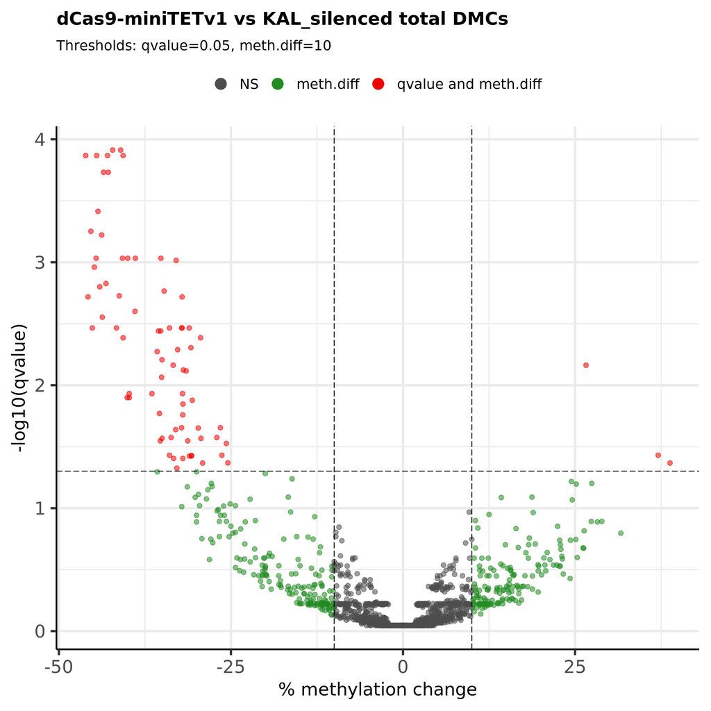